# Robert Carter Final Presentation Data Science Praticum

Robert Carter

3/8/2021

The data that I am working with is the Jane Street Data Market Predicition Data from Kaggle. I am going to try and create a model to predict whether to trade or not.

Loading in Libraries for Analysis

```r
library(tidyverse)
library(data.table)
library(timereg)
library(rlang)
library(torch)
library(epiDisplay)
```

Loading two of the main data sets. I am reducing mu dataset to 1,000,000 records so that I am able to get results without killing my machince. The Train dataset has over 2 million rows.

```r
train <- fread("/Users/robertcarter/Desktop/jane-street-market-prediction/train.csv", nrows = 1000000)
features <- fread("/Users/robertcarter/Desktop/jane-street-market-prediction/features.csv")
```

```r
summary(train)
```

```
##       date            weight             resp_1               resp_2
##  Min.   :  0.00   Min.   :  0.0000   Min.   :-0.3675043   Min.   :-0.5328334
##  1st Qu.: 39.00   1st Qu.:  0.1244   1st Qu.:-0.0019555   1st Qu.:-0.0028109
##  Median : 81.00   Median :  0.6263   Median : 0.0000767   Median : 0.0001047
##  Mean   : 92.09   Mean   :  2.7355   Mean   : 0.0002218   Mean   : 0.0002802
##  3rd Qu.:148.00   3rd Qu.:  2.2134   3rd Qu.: 0.0022998   3rd Qu.: 0.0032072
##  Max.   :208.00   Max.   :165.4424   Max.   : 0.2453477   Max.   : 0.2949339
##
##      resp_3               resp_4                resp
##  Min.   :-0.5681196   Min.   :-0.5986096   Min.   :-0.5493845
##  1st Qu.:-0.0053006   1st Qu.:-0.0098888   1st Qu.:-0.0075983
##  Median : 0.0001858   Median : 0.0002362   Median : 0.0001733
##  Mean   : 0.0004638   Mean   : 0.0007682   Mean   : 0.0006403
##  3rd Qu.: 0.0060112   3rd Qu.: 0.0107710   3rd Qu.: 0.0081909
##  Max.   : 0.3265597   Max.   : 0.5113795   Max.   : 0.4484616
##
##    feature_0           feature_1          feature_2          feature_3
##  Min.   :-1.000000   Min.   :-3.17203   Min.   :-3.09318   Min.   :-25.4247
##  1st Qu.:-1.000000   1st Qu.:-1.21964   1st Qu.:-1.29301   1st Qu.: -1.0964
##  Median : 1.000000   Median : 0.06503   Median :-0.01513   Median :  0.0073
##  Mean   : 0.009234   Mean   : 0.47859   Mean   : 0.36998   Mean   :  0.0158
##  3rd Qu.: 1.000000   3rd Qu.: 1.65669   3rd Qu.: 1.53468   3rd Qu.:  1.1299
##  Max.   : 1.000000   Max.   :74.42989   Max.   :89.89292   Max.   : 25.8717
##                                                            NA's   :325
##    feature_4          feature_5           feature_6           feature_7
##  Min.   :-19.1188   Min.   :-32.52228   Min.   :-40.73895   Min.   :-28.16
##  1st Qu.: -0.9969   1st Qu.: -1.01207   1st Qu.: -0.95197   1st Qu.: -0.81
##  Median :  0.0023   Median :  0.00353   Median :  0.00138   Median :  0.01
##  Mean   :  0.0116   Mean   :  0.00646   Mean   : -0.00133   Mean   :  0.07
##  3rd Qu.:  1.0242   3rd Qu.:  1.02392   3rd Qu.:  0.95836   3rd Qu.:  0.93
##  Max.   : 19.4218   Max.   : 32.74220   Max.   : 40.71510   Max.   : 29.62
##  NA's   :325                                                NA's   :159947
##    feature_8        feature_9           feature_10         feature_11
##  Min.   :-41.88   Min.   :-161.5690   Min.   :-88.2770   Min.   :-49.29
##  1st Qu.: -0.93   1st Qu.:  -1.1567   1st Qu.: -0.7975   1st Qu.: -0.69
##  Median :  0.00   Median :   0.0806   Median :  0.0106   Median :  0.02
##  Mean   :  0.04   Mean   :   0.3687   Mean   :  0.2179   Mean   :  0.12
##  3rd Qu.:  0.98   3rd Qu.:   1.6101   3rd Qu.:  1.0011   3rd Qu.:  0.86
##  Max.   : 40.68   Max.   : 157.4156   Max.   : 91.9661   Max.   : 51.16
##  NA's   :159947   NA's   :365         NA's   :365        NA's   :32515
```

[output cut: 233 more lines]

```
##  Min.   :-8.215   Min.   :-5.429   Min.   :-7.0249   Min.   : -4.9997
##  1st Qu.:-1.326   1st Qu.:-0.876   1st Qu.:-1.1562   1st Qu.: -0.8109
##  Median : 0.025   Median : 0.041   Median : 0.0327   Median :  0.0493
##  Mean   : 0.469   Mean   : 0.330   Mean   : 0.4603   Mean   :  0.3401
##  3rd Qu.: 1.818   3rd Qu.: 1.238   3rd Qu.: 1.6318   3rd Qu.:  1.2420
##  Max.   :58.728   Max.   :62.046   Max.   :51.1904   Max.   :116.4568
##  NA's   :3527     NA's   :3527     NA's   :891       NA's   :891
##      ts_id
##  Min.   :     0
##  1st Qu.:250000
##  Median :500000
##  Mean   :500000
##  3rd Qu.:749999
##  Max.   :999999
##
```

Going to check how many rows do nothave 0 in the data to make sure there is enough data to evaluate. Rows with zero take up about 19% of the data. By removing the 0 we will still have a significant amount of data to complete our analysis.

```r
length(train$weight[train$weight != 0])
```

```
## [1] 800128
```

```r
length(train$weight[train$weight == 0])/nrow(train)
```

```
## [1] 0.199872
```

Now we are going to take a look at the number of trades by date. It looks like the trades are pretty spread out evenly. I bulk of the trades happen around day 40.

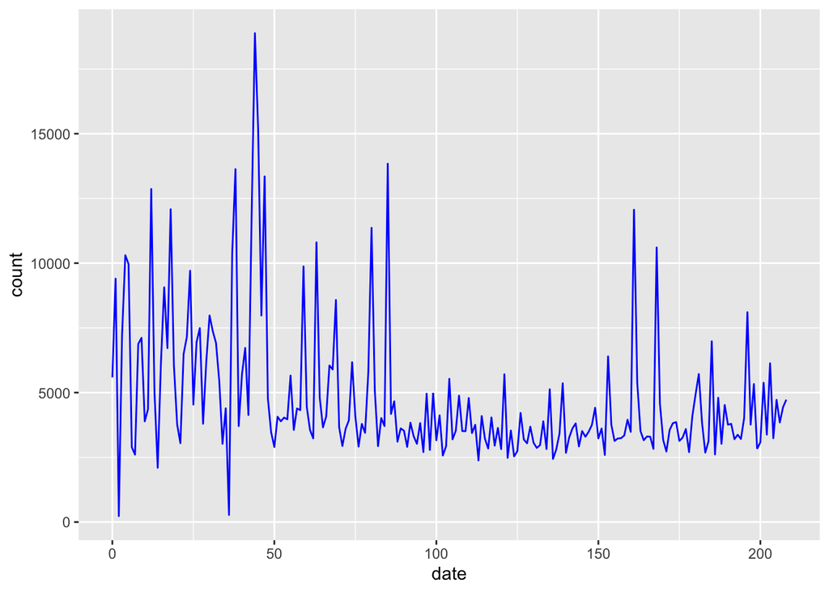

```r
trades_by_date <- train[ , .(count = .N), by=date]
p <- ggplot(data = trades_by_date, aes(x = date, y = count))
p + geom_line(color = "blue")
```

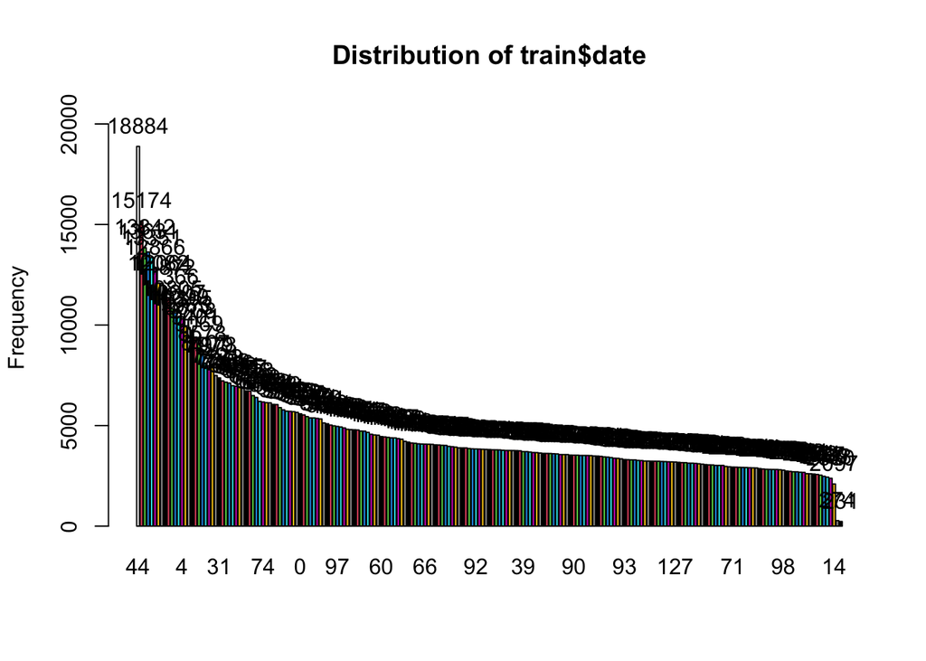

```
## train$date :
##         Frequency Percent Cum. percent
## 44          18884     1.9          1.9
## 45          15174     1.5          3.4
## 85          13842     1.4          4.8
## 38          13631     1.4          6.2
## 47          13351     1.3          7.5
## 12          12866     1.3          8.8
## 18          12082     1.2         10.0
## 161         12064     1.2         11.2
## 43          11872     1.2         12.4
## 80          11366     1.1         13.5
## 63          10805     1.1         14.6
## 168         10607     1.1         15.7
## 37          10399     1.0         16.7
```

[output cut: 197 more lines]

```r
tab1(train$date, sort.group = "decreasing", cum.percent = TRUE)
```

Checking the mean resp for weights greater than 0 and weights that equal zero. It looks like the mean is significantly higher for the weights without zero so my theory holds true and I will remove the trades that have zero weight.

```r
mean(train$resp[train$weigh>0])
```

```
## [1] 0.0007791776
```

```r
mean(train$resp[train$weigh==0])
```

```
## [1] 8.439452e-05
```

Going to load the dataset with trade weights greater than 0 and update the train table.

```r
train_no0 <- train[which(train$weight > 0),]
train <- train_no0
```

Going to take a quick look at weights. It appears that a majority of the weights have a lower value

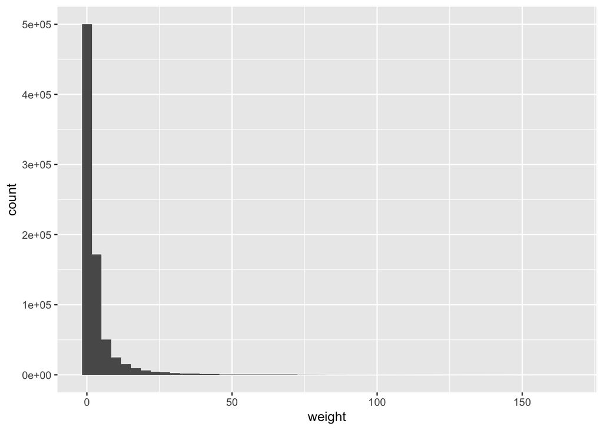

```r
p <- ggplot(train, aes(x = weight))
p + geom_histogram( bins = 50)
```

Now we are going to start preparing the data for linear and logistic regrerssion. I am looking at both to see the significant fields in the data. Also, I am going to scale the data to stardardize the data and clean up any NA values. Also, I am going to break the data into a train and test set and make both y train and y test binomial for our logistic regression since we are trying to determine whether to trade or not trade.

```r
#grabbing only feature column
feature_cols <- which(grepl("feature", colnames(train)))
x <- train[, feature_cols, with = FALSE]
#checking for NA
any(is.na(x))
```

```
## [1] TRUE
```

```r
for(j in 1:length(feature_cols)){
  if(any(is.na(x[,j, with=FALSE]))){
  }
}

for(j in 1:length(feature_cols)){
  set(x, i = which(is.na(x[[j]])), j = j, value = mean(train[[j]], na.rm=TRUE))
}
#Rechecking for NA
any(is.na(x))
```

```
## [1] FALSE
```

```r
x <- scale(x)

train_end <- floor(0.75 * nrow(train))
test_start <- train_end + 1
test_end <- nrow(train)
x_train <- x[1:train_end,]
y_train <- as.numeric(train[["resp"]]>0)[1:train_end]
x_test <- x[test_start:test_end,]
y_test <- as.numeric(train[["resp"]]>0)[test_start:test_end]
train_data <- cbind.data.frame(y_train, x_train)
test_data <- cbind.data.frame(y_test, x_test)
head(train_data[1:10,1:10])
```

```
##   y_train  feature_0   feature_1  feature_2   feature_3   feature_4
## 1       0 -0.9996245 -0.72873859 -0.8538397  0.03451404  0.02336504
## 2       0  1.0003744 -1.40659753 -1.4021673 -0.07129549 -0.06158303
## 3       1 -0.9996245 -1.40659753 -1.4021673 -0.01095101 -0.01548322
## 4       1 -0.9996245 -0.06088572 -0.3647388  0.23301763  0.14037683
## 5       0  1.0003744 -1.40659753 -1.4021673 -0.16454277 -0.15020123
## 6       1  1.0003744  0.79396827  0.3770427 -0.11244569 -0.07959895
##      feature_5    feature_6   feature_7 feature_8
## 1  0.101039582  0.086672455 -0.03866126 0.2548673
## 2 -0.102890410 -0.075062877 -0.03866126 0.2548673
## 3  0.050300712  0.038076803 -0.03866126 0.2548673
## 4  0.215768202  0.135955774 -0.03866126 0.2548673
## 5  0.066751041  0.062558472 -0.03866126 0.2548673
## 6  0.006881921  0.002431352 -0.03866126 0.2548673
```

names(train_data)

Linear Regression has over 40 significant columns. This is just a simple model to check the significance of the data. A logistic regression will be better since the data is not linear that we are looking.

```r
#Linear Regression
lmfit <- lm(resp ~ . -resp_1 - resp_2 - resp_3 - resp_4, data = train)
summary(lmfit)
```

```
##
## Call:
## lm(formula = resp ~ . - resp_1 - resp_2 - resp_3 - resp_4, data = train)
##
## Residuals:
##      Min       1Q   Median       3Q      Max
## -0.55791 -0.00823 -0.00006  0.00785  0.44790
##
## Coefficients:
##               Estimate Std. Error t value Pr(>|t|)
## (Intercept)  1.077e-03  1.590e-04   6.773 1.27e-11 ***
## date         2.215e-05  4.560e-06   4.858 1.19e-06 ***
## weight       4.044e-05  1.456e-05   2.777 0.005481 **
## feature_0    3.456e-04  1.192e-04   2.899 0.003744 **
## feature_1    2.658e-04  1.012e-04   2.627 0.008607 **
## feature_2   -2.020e-04  1.015e-04  -1.990 0.046637 *
## feature_3   -1.450e-03  8.184e-05 -17.714  < 2e-16 ***
## feature_4    1.006e-03  9.814e-05  10.250  < 2e-16 ***
## feature_5   -4.751e-05  6.341e-05  -0.749 0.453761
## feature_6    1.493e-04  6.687e-05   2.233 0.025521 *
## feature_7    1.183e-03  9.164e-05  12.913  < 2e-16 ***
## feature_8   -8.682e-04  8.660e-05 -10.026  < 2e-16 ***
## feature_9   -3.178e-05  1.001e-04  -0.317 0.750911
## feature_10  -2.242e-04  1.381e-04  -1.624 0.104475
## feature_11   5.964e-04  1.065e-04   5.598 2.18e-08 ***
## feature_12  -4.308e-04  7.841e-05  -5.494 3.92e-08 ***
## feature_13   2.164e-04  8.145e-05   2.657 0.007887 **
## feature_14  -1.123e-04  9.760e-05  -1.151 0.249739
## feature_15  -2.812e-04  1.163e-04  -2.419 0.015572 *
## feature_16   4.237e-04  9.978e-05   4.247 2.17e-05 ***
## feature_17  -2.821e-03  1.341e-04 -21.034  < 2e-16 ***
## feature_18   1.741e-03  1.099e-04  15.844  < 2e-16 ***
## feature_19   3.431e-04  2.006e-04   1.711 0.087136 .
## feature_20   2.888e-04  1.924e-04   1.501 0.133324
## feature_21   1.554e-05  1.043e-04   0.149 0.881608
## feature_22   6.984e-05  1.281e-04   0.545 0.585640
## feature_23  -7.402e-05  1.536e-04  -0.482 0.629886
## feature_24  -1.561e-04  1.305e-04  -1.196 0.231615
## feature_25   4.148e-04  2.077e-04   1.997 0.045772 *
## feature_26  -4.064e-04  1.906e-04  -2.132 0.032983 *
```

[output cut: 96 more lines]

```
## feature_123  2.984e-04  1.817e-04   1.642 0.100564
## feature_124  6.613e-04  2.768e-04   2.389 0.016888 *
## feature_125 -6.279e-04  1.663e-04  -3.775 0.000160 ***
## feature_126 -5.162e-04  2.613e-04  -1.975 0.048224 *
## feature_127  7.820e-04  2.452e-04   3.190 0.001424 **
## feature_128 -2.495e-05  3.260e-04  -0.077 0.938982
## feature_129 -2.167e-04  2.706e-04  -0.801 0.423242
## ts_id       -5.124e-09  9.885e-10  -5.183 2.18e-07 ***
## ---
## Signif. codes:  0 '***' 0.001 '**' 0.01 '*' 0.05 '.' 0.1 ' ' 1
##
## Residual standard error: 0.02861 on 674790 degrees of freedom
##   (125204 observations deleted due to missingness)
## Multiple R-squared:  0.009864,   Adjusted R-squared:  0.009669
## F-statistic: 50.54 on 133 and 674790 DF,  p-value: < 2.2e-16
```

Logistic Regression to get accuracy of data. The data was spilt into training and test datasets. Going to train the model first. Then run the test data to see what our accuracy will be.There seems to be quite a few significanrt varaibles here as well as in the linear regression. Logistic regression is better for this data because we are trying to determine wheter to trade or not trade therefore we set the family to bionomial since we are only looking at two option. It turns out that we were able to get a 51 percent accuracy.

```r
glm.fit <- glm(y_train ~ ., data = train_data, family = binomial)
summary(glm.fit)
```

```
##
## Call:
## glm(formula = y_train ~ ., family = binomial, data = train_data)
##
## Deviance Residuals:
##    Min      1Q  Median      3Q     Max
## -2.234  -1.193   1.034   1.154   1.772
##
## Coefficients:
##               Estimate Std. Error z value Pr(>|z|)
## (Intercept)  0.0452216  0.0026038  17.368  < 2e-16 ***
## feature_0   -0.0904075  0.0084537 -10.694  < 2e-16 ***
## feature_1    0.0774807  0.0200096   3.872 0.000108 ***
## feature_2   -0.0522711  0.0192466  -2.716 0.006610 **
## feature_3   -0.1302677  0.0132511  -9.831  < 2e-16 ***
## feature_4    0.1014783  0.0140136   7.241 4.44e-13 ***
## feature_5    0.0013894  0.0085485   0.163 0.870885
## feature_6   -0.0063249  0.0085591  -0.739 0.459926
## feature_7    0.0578772  0.0117515   4.925 8.43e-07 ***
## feature_8   -0.0371411  0.0124535  -2.982 0.002860 **
## feature_9    0.0452518  0.0171120   2.644 0.008182 **
## feature_10  -0.0347709  0.0170603  -2.038 0.041538 *
## feature_11   0.0170722  0.0121925   1.400 0.161448
## feature_12   0.0122722  0.0127479   0.963 0.335707
## feature_13   0.0163938  0.0135437   1.210 0.226112
## feature_14   0.0004414  0.0141784   0.031 0.975167
## feature_15  -0.0077126  0.0154837  -0.498 0.618404
## feature_16   0.0085772  0.0158852   0.540 0.589232
## feature_17  -0.0750776  0.0148297  -5.063 4.14e-07 ***
## feature_18   0.0678435  0.0149246   4.546 5.47e-06 ***
## feature_19  -0.0776632  0.0239112  -3.248 0.001162 **
## feature_20   0.1224993  0.0259023   4.729 2.25e-06 ***
## feature_21  -0.0334870  0.0178365  -1.877 0.060457 .
## feature_22   0.0117281  0.0162632   0.721 0.470819
## feature_23  -0.0391394  0.0215302  -1.818 0.069082 .
## feature_24   0.0112806  0.0222964   0.506 0.612900
## feature_25   0.0515026  0.0304640   1.691 0.090912 .
## feature_26  -0.0461683  0.0305211  -1.513 0.130364
## feature_27  -0.1248387  0.0150706  -8.284  < 2e-16 ***
## feature_28   0.1269622  0.0162147   7.830 4.88e-15 ***
```

[output cut: 96 more lines]

```
## feature_125  0.0069453  0.0165164   0.421 0.674114
## feature_126  0.0614690  0.0390817   1.573 0.115757
## feature_127 -0.0173022  0.0244294  -0.708 0.478789
## feature_128 -0.0566590  0.0469410  -1.207 0.227422
## feature_129  0.0091932  0.0278886   0.330 0.741672
## ---
## Signif. codes:  0 '***' 0.001 '**' 0.01 '*' 0.05 '.' 0.1 ' ' 1
##
## (Dispersion parameter for binomial family taken to be 1)
##
##     Null deviance: 831578  on 600095  degrees of freedom
## Residual deviance: 828580  on 599965  degrees of freedom
## AIC: 828842
##
## Number of Fisher Scoring iterations: 3
```

```r
glm.probs <- predict(glm.fit, newdata = test_data, type=c("response"))
if (!require(pROC)) install.packages("pROC", verbose=TRUE)
auc <- roc(y_test ~ glm.probs, data = cbind.data.frame(y_test, x_test))
auc
```

```
##
## Call:
## roc.formula(formula = y_test ~ glm.probs, data = cbind.data.frame(y_test,     x_test))
##
## Data: glm.probs in 99081 controls (y_test 0) < 100951 cases (y_test 1).
## Area under the curve: 0.5256
```

```r
glm.pred <- ifelse(glm.probs > 0.5, 1, 0)
mean(glm.pred == y_test)
```

```
## [1] 0.5171373
```

Last, I am going to retry the logistic model but only using the significant fields to see if that will increase the accuracy.

```r
#using only significant data
train_sig <-  dplyr::select(train, date, weight, resp, feature_0, feature_1, feature_2,feature_3, feature_4, feature_7, feature_8, feature_9, feature_10,
                            feature_17, feature_18, feature_19, feature_20,feature_27, feature_28,feature_29, feature_30, feature_31, feature_32, feature_37,
                            feature_38, feature_39, feature_40, feature_43, feature_44,feature_45, feature_46, feature_48, feature_49, feature_53, feature_54,
                            feature_55, feature_57, feature_62, feature_63, feature_64, feature_67,feature_68, feature_69,feature_71, feature_77, feature_86, feature_92,
                            feature_96, feature_97, feature_101, feature_107, feature_108, feature_109, feature_110, feature_116, feature_118, feature_119)
```

After rereunning the logistic regression model with only significant data from before the results became slightly worse. The maximum model we were able to produce had 51 percent accuracy.

```r
#resetting x
feature_cols2 <- which(grepl("feature", colnames(train_sig)))
x2 <- train_sig[, feature_cols2, with = FALSE]
any(is.na(x2))
```

```
## [1] TRUE
```

```r
for(j in 1:length(feature_cols2)){
  if(any(is.na(x2[,j, with=FALSE]))){

  }
}

for(j in 1:length(feature_cols2)){
  set(x2, i = which(is.na(x2[[j]])), j = j, value = mean(train_sig[[j]], na.rm=TRUE))
}

any(is.na(x2))
```

```
## [1] FALSE
```

```r
x2 <- scale(x2)

train_end2 <- floor(0.8 * nrow(train_sig))
test_start2 <- train_end2 + 1
test_end2 <- nrow(train_sig)
x_train2 <- x2[1:train_end2,]
y_train2 <- as.numeric(train_sig[["resp"]]>0)[1:train_end2]
x_test2 <- x2[test_start2:test_end2,]
y_test2 <- as.numeric(train_sig[["resp"]]>0)[test_start2:test_end2]
train_data2 <- cbind.data.frame(y_train2, x_train2)
test_data2 <- cbind.data.frame(y_test2, x_test2)


glm.fit2 <- glm(y_train2 ~ ., data = train_data2, family = binomial)

glm.probs2 <- predict(glm.fit2, newdata = test_data2, type=c("response"))
if (!require(pROC)) install.packages("pROC", verbose=TRUE)
auc2 <- roc(y_test2 ~ glm.probs2, data = cbind.data.frame(y_test2, x_test2))
auc2
```

```
##
## Call:
## roc.formula(formula = y_test2 ~ glm.probs2, data = cbind.data.frame(y_test2,     x_test2))
##
## Data: glm.probs2 in 79176 controls (y_test2 0) < 80850 cases (y_test2 1).
## Area under the curve: 0.5258
```

```r
glm.pred2 <- ifelse(glm.probs2 > 0.5, 1, 0)
mean(glm.pred2 == y_test2)
```

```
## [1] 0.5169972
```